# Regresión Lineal (segunda sesión, ejemplo 1)

Mario Encinar

```r
library(dplyr)
library(car)
library(leaps)
```

# Modelo de regresión lineal con el dataset Auto

El objetivo de este ejercicio es ajustar un modelo que permita predecir mpg en términos del resto de variables del set de datos.

```r
Auto <- read.csv('Auto.csv', header = T, sep = ';')
glimpse(Auto)
```

```
## Observations: 392
## Variables: 9
## $ mpg          <dbl> 18, 15, 18, 16, 17, 15, 14, 14, 14, 15, 15, 14, 1...
## $ cylinders    <int> 8, 8, 8, 8, 8, 8, 8, 8, 8, 8, 8, 8, 8, 8, 4, 6, 6...
## $ displacement <dbl> 307, 350, 318, 304, 302, 429, 454, 440, 455, 390,...
## $ horsepower   <int> 130, 165, 150, 150, 140, 198, 220, 215, 225, 190,...
## $ weight       <int> 3504, 3693, 3436, 3433, 3449, 4341, 4354, 4312, 4...
## $ acceleration <dbl> 12.0, 11.5, 11.0, 12.0, 10.5, 10.0, 9.0, 8.5, 10....
## $ year         <int> 70, 70, 70, 70, 70, 70, 70, 70, 70, 70, 70, 70, 7...
## $ origin       <int> 1, 1, 1, 1, 1, 1, 1, 1, 1, 1, 1, 1, 1, 1, 3, 1, 1...
## $ name         <fct> chevrolet chevelle malibu, buick skylark 320, ply...
```

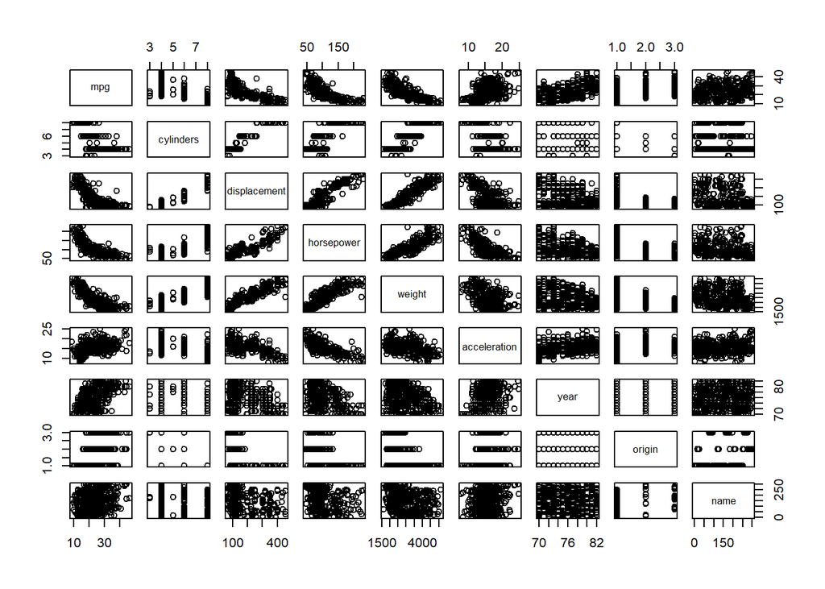

```r
pairs(Auto)
```

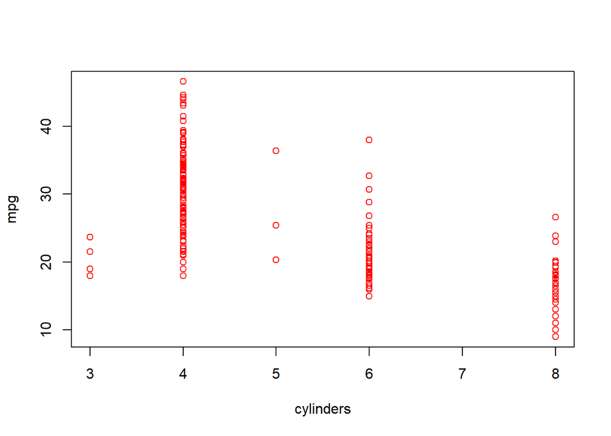

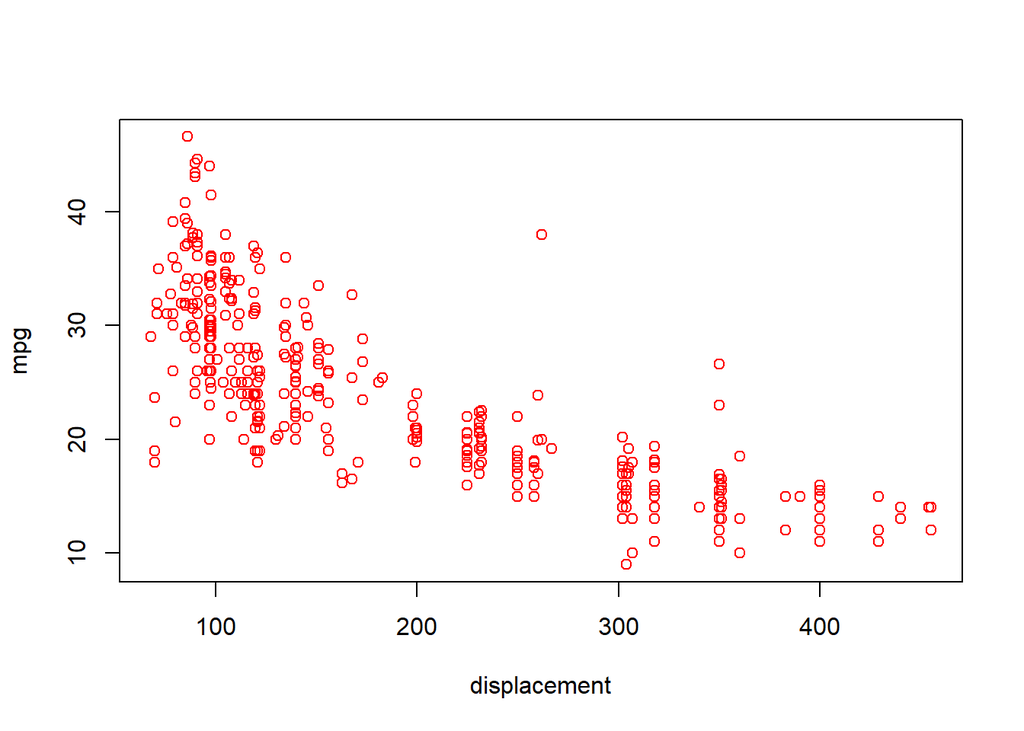

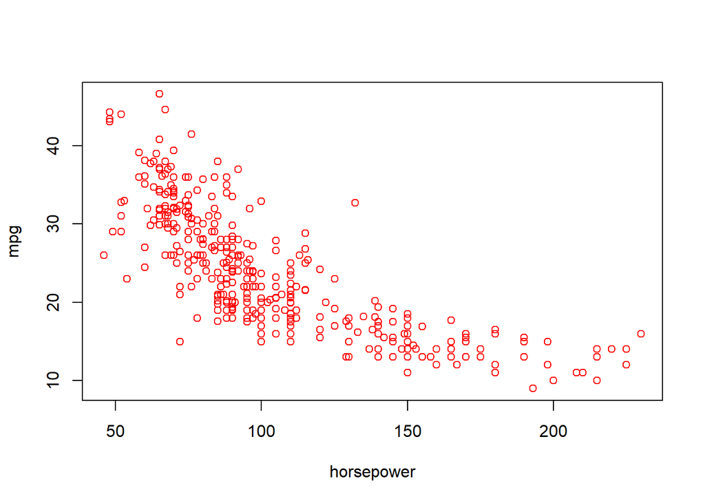

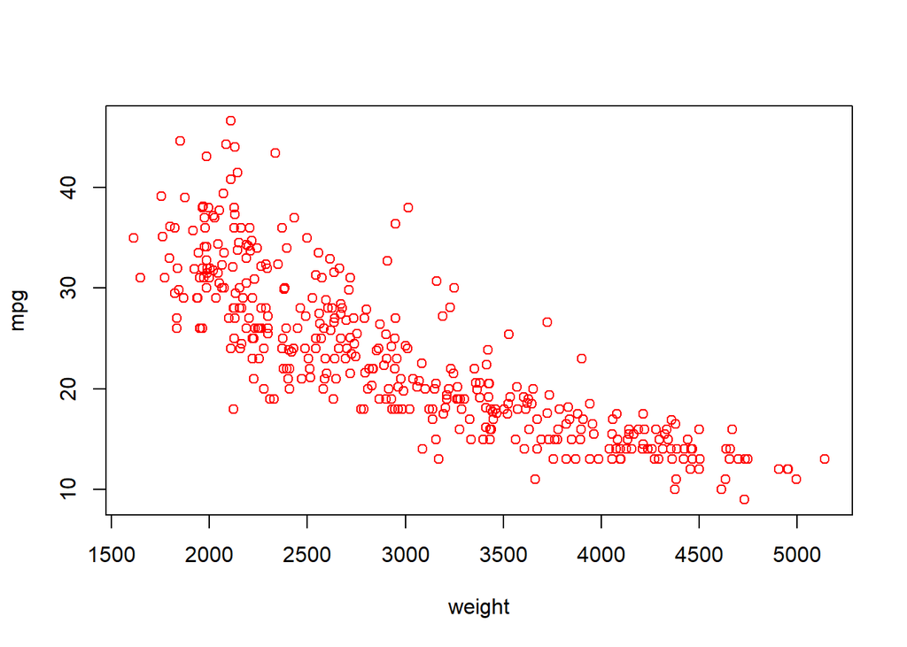

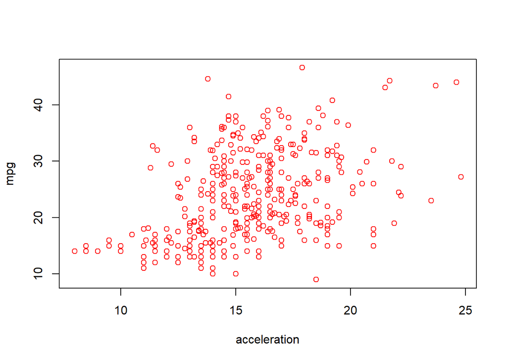

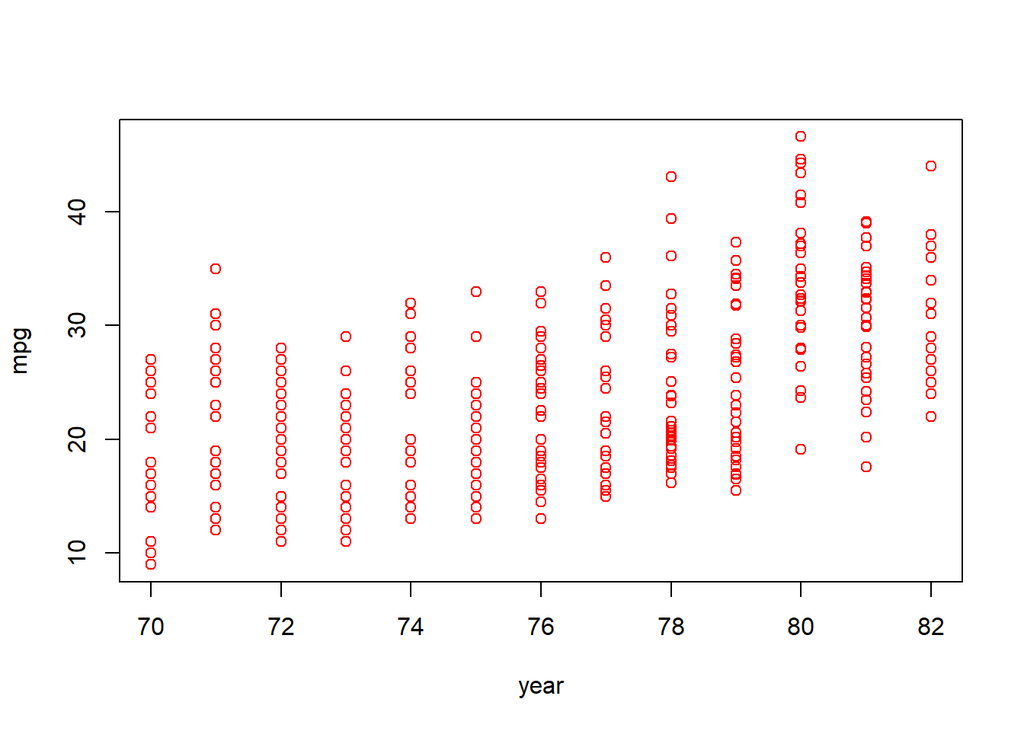

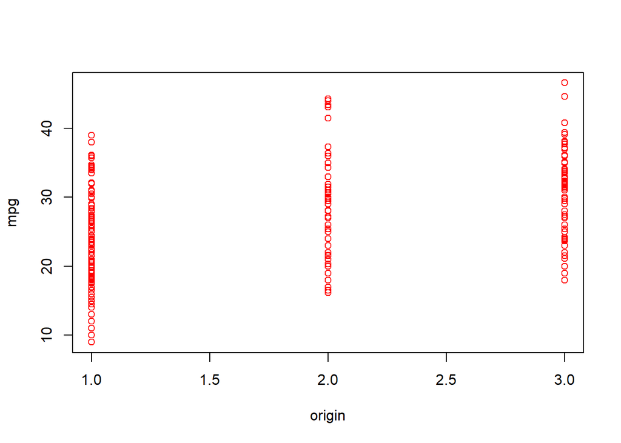

```r
for(i in 2:8){
  plot(Auto[,i], Auto$mpg, type = 'p', col = 'red', xlab = names(Auto)[i], ylab = 'mpg')
}
```

Se observa que cylinders, origin y name son variables categóricas. Descartamos la última por sencillez. La primera puede tratarse como si fuera numérica, pero no así la segunda.

```r
Auto$origin <- ifelse(Auto$origin == 1, 'American',
                      ifelse(Auto$origin == 2, 'European', 'Japanese'))
```

## Ajuste de un modelo de regresión lineal

En primer lugar, probamos “best subset selection” para construir un modelo.

```r
exhaustive.model <- regsubsets(mpg ~ . - name, data = Auto)

summary(exhaustive.model)
```

```
## Subset selection object
## Call: regsubsets.formula(mpg ~ . - name, data = Auto)
## 8 Variables  (and intercept)
##                Forced in Forced out
## cylinders          FALSE      FALSE
## displacement       FALSE      FALSE
## horsepower         FALSE      FALSE
## weight             FALSE      FALSE
## acceleration       FALSE      FALSE
## year               FALSE      FALSE
## originEuropean     FALSE      FALSE
## originJapanese     FALSE      FALSE
## 1 subsets of each size up to 8
## Selection Algorithm: exhaustive
##          cylinders displacement horsepower weight acceleration year
## 1  ( 1 ) " "       " "          " "        "*"    " "          " "
## 2  ( 1 ) " "       " "          " "        "*"    " "          "*"
## 3  ( 1 ) " "       " "          " "        "*"    " "          "*"
## 4  ( 1 ) " "       " "          " "        "*"    " "          "*"
## 5  ( 1 ) " "       "*"          " "        "*"    " "          "*"
## 6  ( 1 ) " "       "*"          "*"        "*"    " "          "*"
## 7  ( 1 ) "*"       "*"          "*"        "*"    " "          "*"
## 8  ( 1 ) "*"       "*"          "*"        "*"    "*"          "*"
##          originEuropean originJapanese
## 1  ( 1 ) " "            " "
## 2  ( 1 ) " "            " "
## 3  ( 1 ) " "            "*"
## 4  ( 1 ) "*"            "*"
## 5  ( 1 ) "*"            "*"
## 6  ( 1 ) "*"            "*"
## 7  ( 1 ) "*"            "*"
## 8  ( 1 ) "*"            "*"
```

¿Cómo son los R2 en cada caso?

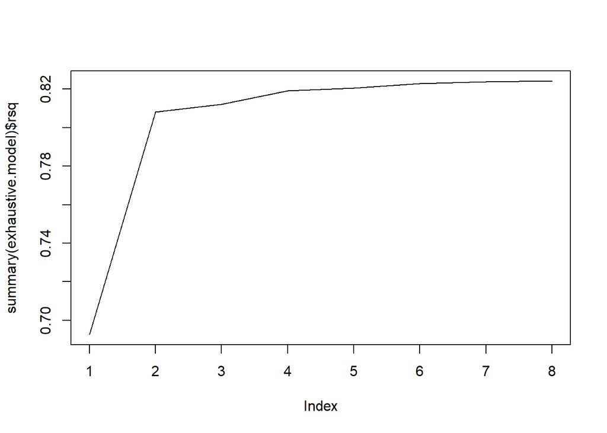

```r
plot(summary(exhaustive.model)$rsq, type = 'l')
```

Por el criterio “del codo”, tiene sentido tomar dos o cuatro variables. Probamos con cuatro (en este caso, resultan ser weight, year y origin).

```r
mpg_fit_wyo <- lm(mpg ~ weight + year + origin, data = Auto)
summary(mpg_fit_wyo)
```

```
##
## Call:
## lm(formula = mpg ~ weight + year + origin, data = Auto)
##
## Residuals:
##     Min      1Q  Median      3Q     Max
## -9.6025 -2.1132 -0.0206  1.7617 13.5261
##
## Coefficients:
##                  Estimate Std. Error t value Pr(>|t|)
## (Intercept)    -1.831e+01  4.017e+00  -4.557 6.96e-06 ***
## weight         -5.887e-03  2.599e-04 -22.647  < 2e-16 ***
## year            7.698e-01  4.867e-02  15.818  < 2e-16 ***
## originEuropean  1.976e+00  5.180e-01   3.815 0.000158 ***
## originJapanese  2.215e+00  5.188e-01   4.268 2.48e-05 ***
## ---
## Signif. codes:  0 '***' 0.001 '**' 0.01 '*' 0.05 '.' 0.1 ' ' 1
##
## Residual standard error: 3.337 on 387 degrees of freedom
## Multiple R-squared:  0.819,  Adjusted R-squared:  0.8172
## F-statistic: 437.9 on 4 and 387 DF,  p-value: < 2.2e-16
```

Todas las variables tienen relación significativa con la respuesta. Echamos un vistazo a los residuos:

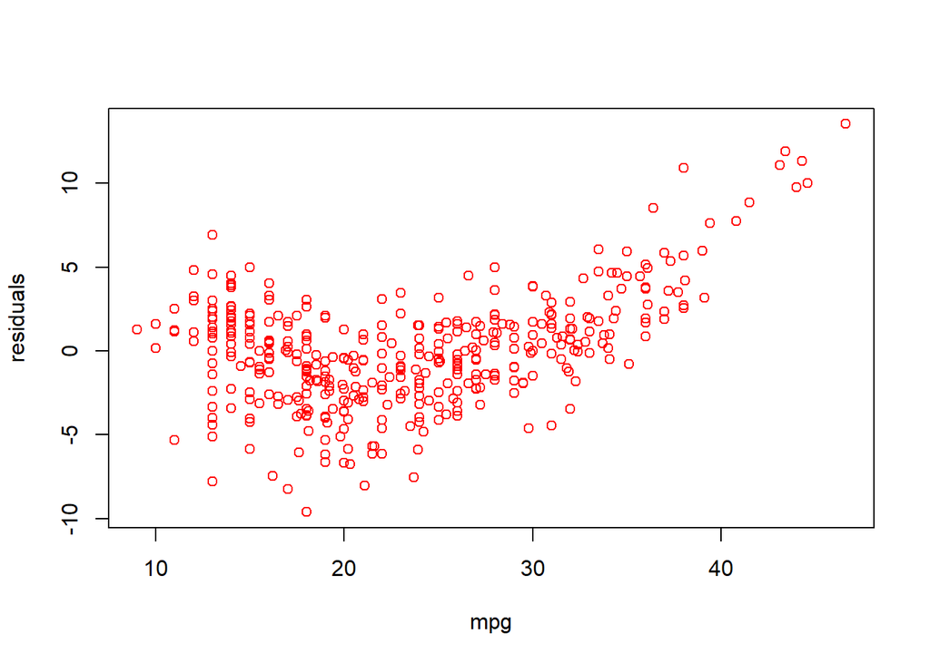

```r
plot(Auto$mpg, mpg_fit_wyo$residuals, col = 'red', xlab = 'mpg', ylab = 'residuals')
```

Se observa que puede haber una relación no lineal y que podría haber outliers (quizá aquellos puntos con residuo mayor que diez en valor absoluto).

En primer lugar, pintamos un boxplot de los residuos para comprobarlo:

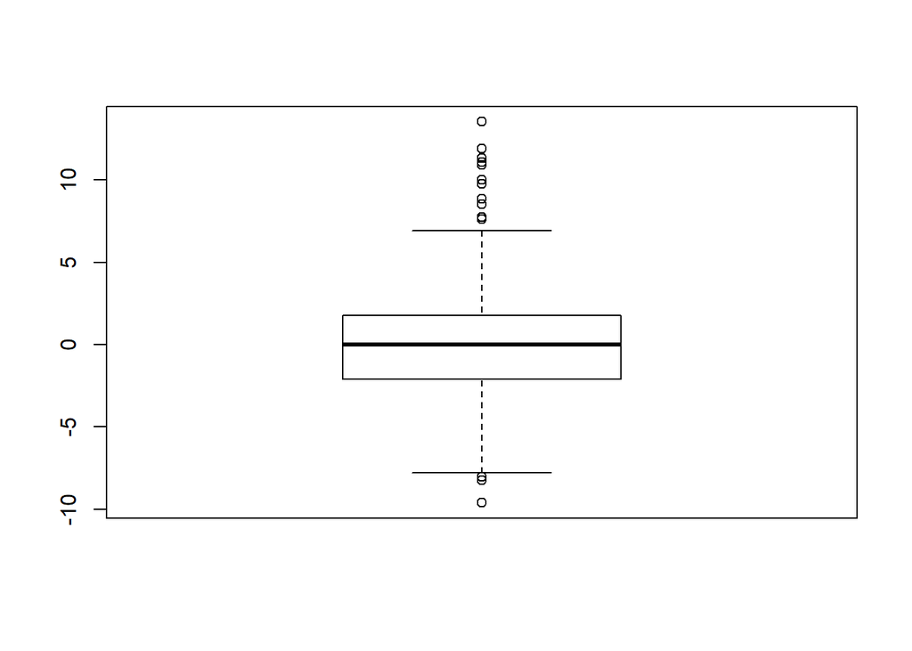

```r
boxplot(mpg_fit_wyo$residuals)
```

Ahora representamos mpg frente a weight y year para analizar la posible relación no lineal existente:

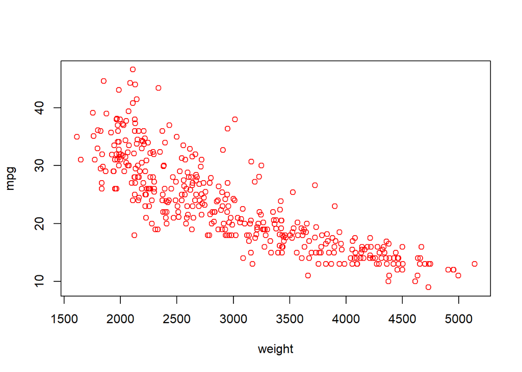

```r
plot(Auto$weight, Auto$mpg, col = 'red', xlab = 'weight', ylab = 'mpg')
```

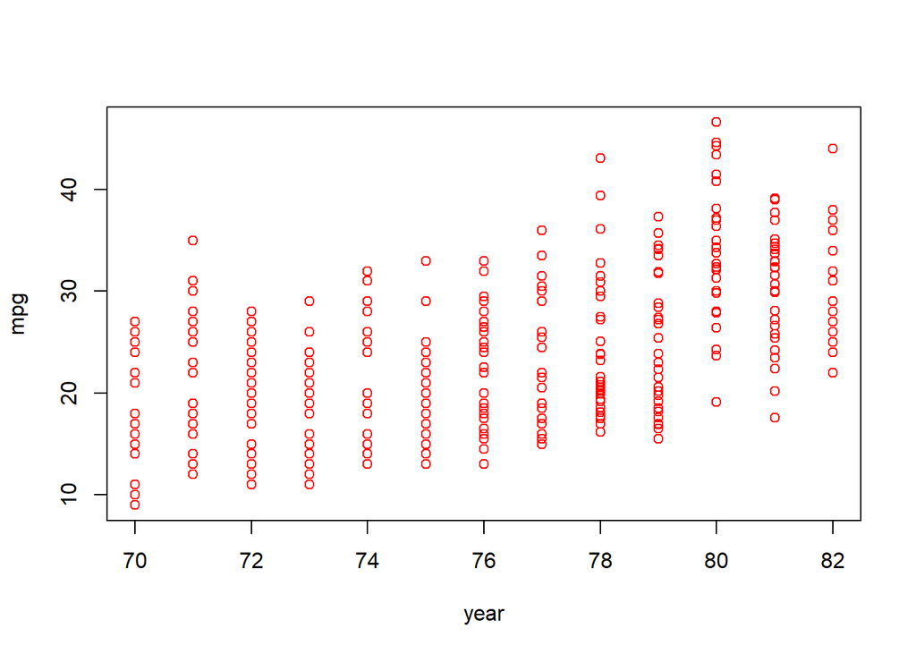

```r
plot(Auto$year, Auto$mpg, col = 'red', xlab = 'year', ylab = 'mpg')
```

Probamos a introducir la variable `weight^2` en el modelo. Para no tener que reescribirlo todo, podemos utilizar la función update.

```r
mpg_fit_wyo_weight2 <- update(mpg_fit_wyo, . ~ . + I(weight^2))
summary(mpg_fit_wyo_weight2)
```

```
##
## Call:
## lm(formula = mpg ~ weight + year + origin + I(weight^2), data = Auto)
##
## Residuals:
##     Min      1Q  Median      3Q     Max
## -9.5415 -1.7074 -0.0552  1.5619 13.0380
##
## Coefficients:
##                  Estimate Std. Error t value Pr(>|t|)
## (Intercept)    -1.379e+00  4.028e+00  -0.342  0.73228
## weight         -2.033e-02  1.530e-03 -13.286  < 2e-16 ***
## year            8.382e-01  4.441e-02  18.875  < 2e-16 ***
## originEuropean  1.366e+00  4.708e-01   2.901  0.00393 **
## originJapanese  9.120e-01  4.867e-01   1.874  0.06169 .
## I(weight^2)     2.218e-06  2.322e-07   9.552  < 2e-16 ***
## ---
## Signif. codes:  0 '***' 0.001 '**' 0.01 '*' 0.05 '.' 0.1 ' ' 1
##
## Residual standard error: 3.005 on 386 degrees of freedom
## Multiple R-squared:  0.8536, Adjusted R-squared:  0.8517
## F-statistic: 450.2 on 5 and 386 DF,  p-value: < 2.2e-16
```

Esto sugiere que quizá podríamos “refactorizar” la variable origin y distinguir entre coches europeos y no europeos únicamente.

```r
Auto$European <- ifelse(Auto$origin == 'European', 1, 0)
candidate_model <- lm(mpg ~ weight + I(weight^2) + year + European, data = Auto)
summary(candidate_model)
```

```
##
## Call:
## lm(formula = mpg ~ weight + I(weight^2) + year + European, data = Auto)
##
## Residuals:
##     Min      1Q  Median      3Q     Max
## -9.1147 -1.6192 -0.0814  1.5316 13.4238
##
## Coefficients:
##               Estimate Std. Error t value Pr(>|t|)
## (Intercept)  3.623e-01  3.932e+00   0.092   0.9266
## weight      -2.135e-02  1.436e-03 -14.871   <2e-16 ***
## I(weight^2)  2.340e-06  2.236e-07  10.463   <2e-16 ***
## year         8.430e-01  4.448e-02  18.954   <2e-16 ***
## European     9.812e-01  4.251e-01   2.308   0.0215 *
## ---
## Signif. codes:  0 '***' 0.001 '**' 0.01 '*' 0.05 '.' 0.1 ' ' 1
##
## Residual standard error: 3.015 on 387 degrees of freedom
## Multiple R-squared:  0.8523, Adjusted R-squared:  0.8508
## F-statistic: 558.3 on 4 and 387 DF,  p-value: < 2.2e-16
```

Analizamos gráficamente el modelo resultante:

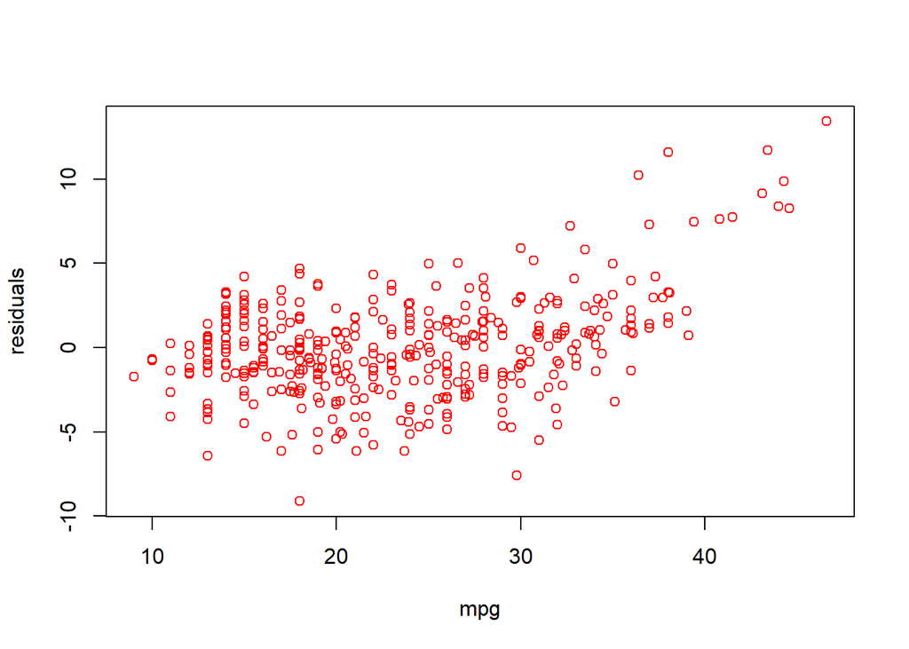

```r
plot(Auto$mpg, candidate_model$residuals, col = 'red', xlab = 'mpg', ylab = 'residuals')
```

Salvo por los outliers (que podrían o no eliminarse), éste es el diagrama de residuos que uno debería esperar.

Estudiamos la presencia de high-leverage points:

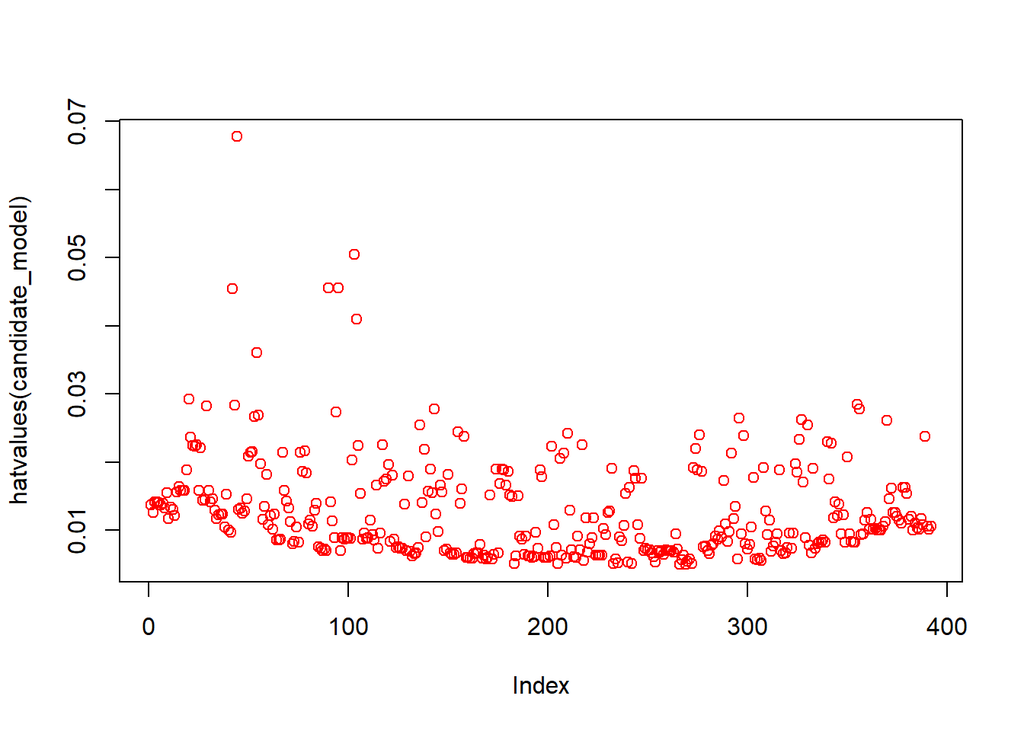

```r
plot(hatvalues(candidate_model), col = 'red')
```

Muy probablemente, la eliminación de los siete puntos con mayor estadístico h mejoraría sensiblemente la bondad de ajuste de nuestro modelo.

Finalmente, estudiamos la colinealidad:

```r
vif(candidate_model)
```

```
##      weight I(weight^2)        year    European
##   63.948320   64.459749    1.154596    1.117123
```

Sorprendentemente, una entre las variables weight y weight2 debe eliminarse, con lo que lo mejor que podemos hacer es volver al modelo que teníamos justo antes de introducir weight2:

```r
summary(mpg_fit_wyo)
```

```
##
## Call:
## lm(formula = mpg ~ weight + year + origin, data = Auto)
##
## Residuals:
##     Min      1Q  Median      3Q     Max
## -9.6025 -2.1132 -0.0206  1.7617 13.5261
##
## Coefficients:
##                  Estimate Std. Error t value Pr(>|t|)
## (Intercept)    -1.831e+01  4.017e+00  -4.557 6.96e-06 ***
## weight         -5.887e-03  2.599e-04 -22.647  < 2e-16 ***
## year            7.698e-01  4.867e-02  15.818  < 2e-16 ***
## originEuropean  1.976e+00  5.180e-01   3.815 0.000158 ***
## originJapanese  2.215e+00  5.188e-01   4.268 2.48e-05 ***
## ---
## Signif. codes:  0 '***' 0.001 '**' 0.01 '*' 0.05 '.' 0.1 ' ' 1
##
## Residual standard error: 3.337 on 387 degrees of freedom
## Multiple R-squared:  0.819,  Adjusted R-squared:  0.8172
## F-statistic: 437.9 on 4 and 387 DF,  p-value: < 2.2e-16
```

Estudiamos la colinealidad en éste:

```r
vif(mpg_fit_wyo)
```

```
##            GVIF Df GVIF^(1/(2*Df))
## weight 1.711383  1        1.308199
## year   1.128435  1        1.062278
## origin 1.612360  2        1.126848
```

Resulta que no hay colinealidad, así que éste es nuestro modelo final.